# R_For_Data_Science_Notes

## POSITION ADJUSTMENT

We can color a bar chart using either colour aesthetic or more usefully fill.

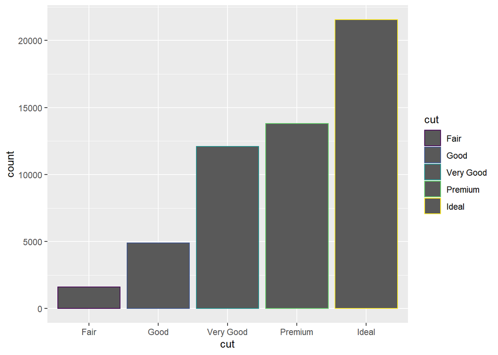

```r
ggplot(data = diamonds) + geom_bar(mapping = aes(x = cut, color = cut))
```

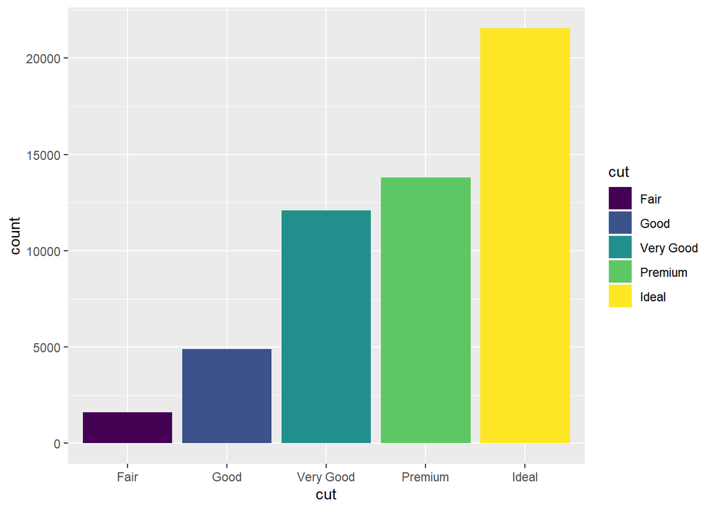

```r
ggplot(data = diamonds) + geom_bar(mapping = aes(x = cut, fill = cut))
```

If we were to map the fill aesthetic to another variable like clarity, the bars are automatically stacked. Each colored rectangle represents a combination of cut and clarity

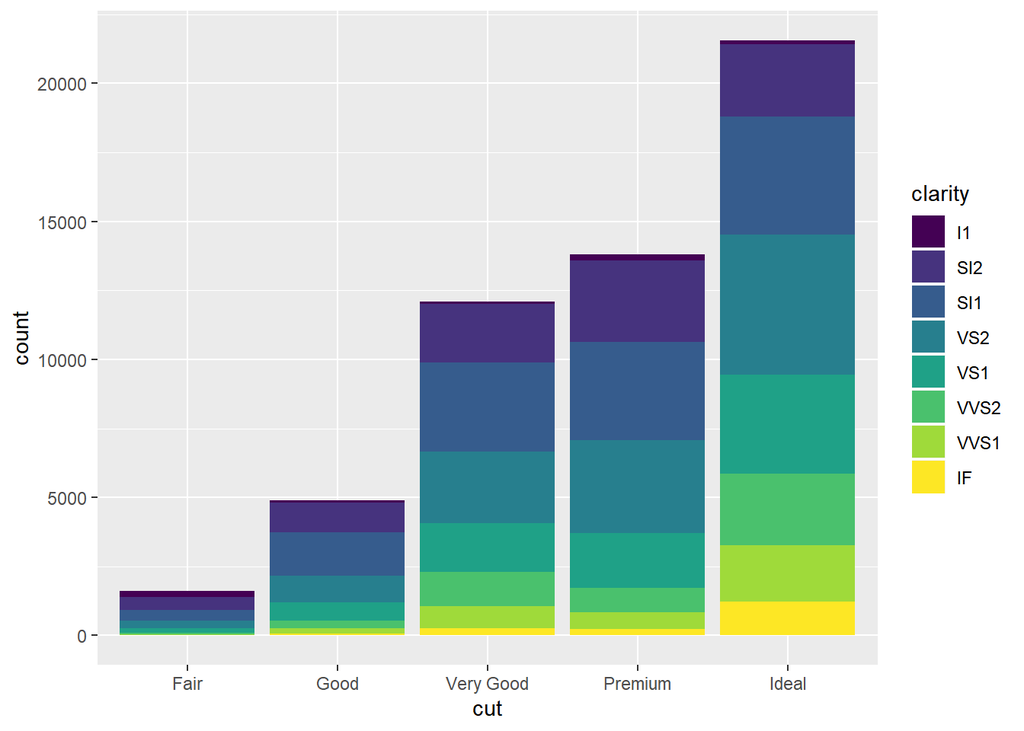

```r
ggplot(data = diamonds) + geom_bar(mapping = aes(x = cut, fill = clarity))
```

`position = "identity"` places each object exactly where it falls in the context of the graph. In bars, however, to see the overlapping we either need to make the bars slightly transparent by setting alpha to a small value, or completely transparent by setting `fill = NA`.

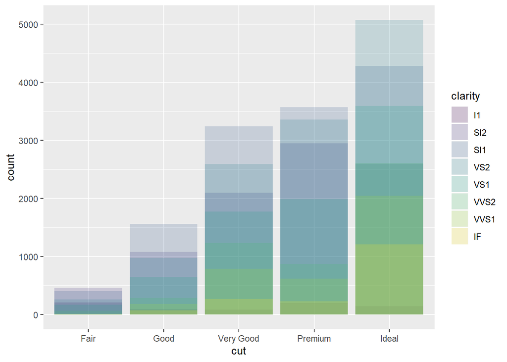

```r
ggplot(data = diamonds, mapping = aes(x = cut, fill = clarity)) + geom_bar(alpha = 1/5, position = "identity")
```

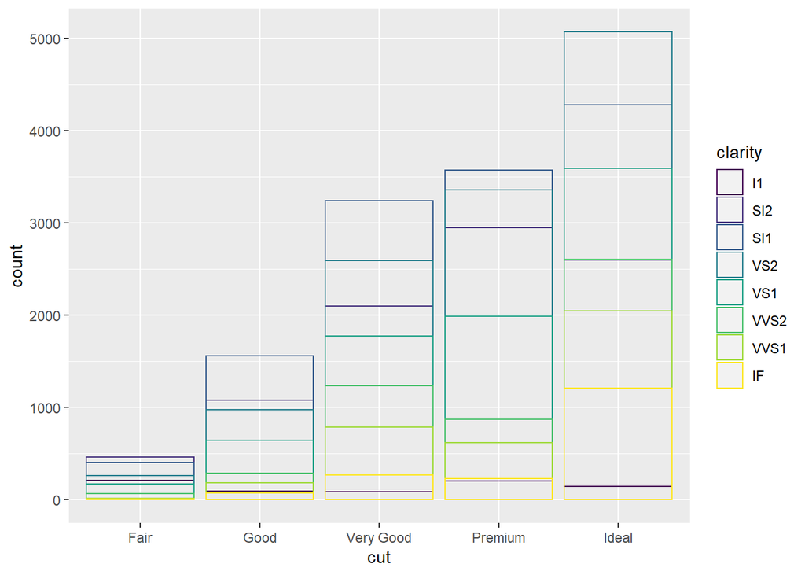

```r
ggplot(data = diamonds, mapping = aes(x = cut, color = clarity)) + geom_bar(fill = NA, position = "identity")
```

`position = "dodge"` places overlapping objects directly beside one another. This makes it easier to compare individual values

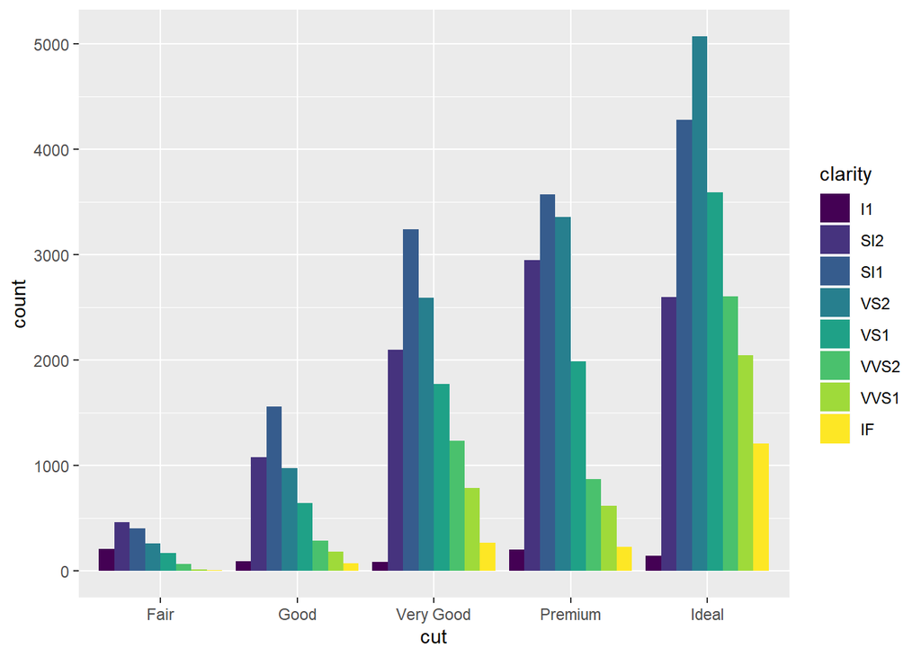

```r
ggplot(data = diamonds) + geom_bar(mapping = aes(x = cut, fill = clarity), position = "dodge")
```

`position = "jitter` adds a small amount of random noise to each point. This spreads the points out because no two points are likely to receive the same amount of random noise

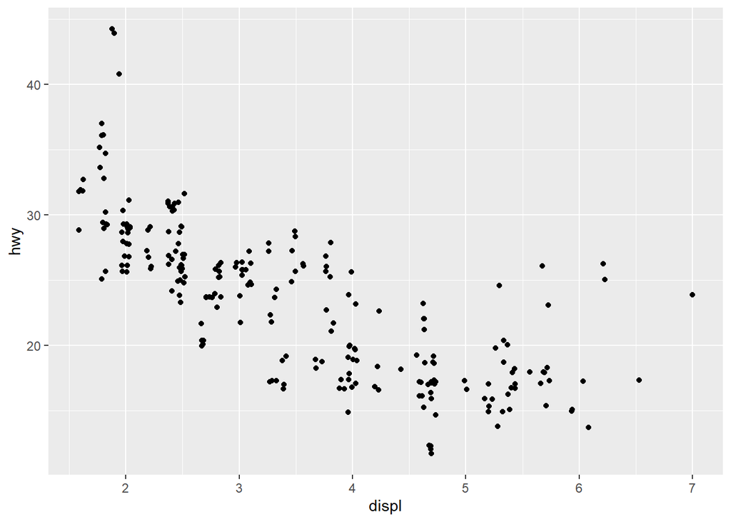

```r
ggplot(data = mpg) + geom_point(mapping = aes(x = displ, y = hwy), position = "jitter")
```